# Bulk RNAseq analysis

Alex Thiery

2023-01-20

### **R tutorial 3**

Previously we carried out differential expression analysis and visualised the outputs in ggplot2. However, sometimes we want to look at the expression of genes associated to a specific developmental process. For this, we will use BioMart to filter genes from our differential expression analysis using GO terms associated to transcription factors and visualise heatmaps of these genes.

#### **Setup working environment**

```r
knitr::opts_knit$set(root.dir = '~/Downloads/')
```

Set working directory

```r
setwd('~/Downloads/')
```

Load libraries

```r
if (!require("biomaRt", quietly = TRUE)){
  install.packages("biomaRt", repos = "http://cran.us.r-project.org")
}

library(biomaRt)
library(pheatmap)
library(DESeq2)
library(dplyr)
```

Set output path

```r
output_path <- './output/'
```

Read in deseq2 output

```r
deseq <- readRDS(paste0(output_path, 'deseq_output.RDS'))
res <- lfcShrink(deseq, coef=c("Group_MCF7_vs_H1"), type = 'apeglm')
rld <- rlog(deseq)
```

First, we want to select the biomart database which provides access to gene annotation information.

```r
ensembl <- useEnsembl(biomart = "genes")
```

Next, we can look at the different datasets available

```r
datasets <- listDatasets(ensembl)
datasets[1:10,]
```

```
##                         dataset                                  description
## 1  abrachyrhynchus_gene_ensembl        Pink-footed goose genes (ASM259213v1)
## 2      acalliptera_gene_ensembl             Eastern happy genes (fAstCal1.2)
## 3    acarolinensis_gene_ensembl              Green anole genes (AnoCar2.0v2)
## 4     acchrysaetos_gene_ensembl              Golden eagle genes (bAquChr1.2)
## 5     acitrinellus_gene_ensembl               Midas cichlid genes (Midas_v5)
## 6     amelanoleuca_gene_ensembl              Giant panda genes (ASM200744v2)
## 7       amexicanus_gene_ensembl Mexican tetra genes (Astyanax_mexicanus-2.0)
## 8       anancymaae_gene_ensembl           Ma's night monkey genes (Anan_2.0)
## 9       aocellaris_gene_ensembl          Clown anemonefish genes (AmpOce1.0)
## 10        apercula_gene_ensembl             Orange clownfish genes (Nemo_v1)
##                   version
## 1             ASM259213v1
## 2              fAstCal1.2
## 3             AnoCar2.0v2
## 4              bAquChr1.2
## 5                Midas_v5
## 6             ASM200744v2
## 7  Astyanax_mexicanus-2.0
## 8                Anan_2.0
## 9               AmpOce1.0
## 10                Nemo_v1
```

We want to select the human dataset as we are working on human cell lines.

```r
ensembl <- useDataset(dataset = "hsapiens_gene_ensembl", mart = ensembl)
```

We can see what attributes we can extract from this database by using the *ListAttributes* function.

```r
listAttributes(ensembl)[1:10,]
```

```
##                             name                  description         page
## 1                ensembl_gene_id               Gene stable ID feature_page
## 2        ensembl_gene_id_version       Gene stable ID version feature_page
## 3          ensembl_transcript_id         Transcript stable ID feature_page
## 4  ensembl_transcript_id_version Transcript stable ID version feature_page
## 5             ensembl_peptide_id            Protein stable ID feature_page
## 6     ensembl_peptide_id_version    Protein stable ID version feature_page
## 7                ensembl_exon_id               Exon stable ID feature_page
## 8                    description             Gene description feature_page
## 9                chromosome_name     Chromosome/scaffold name feature_page
## 10                start_position              Gene start (bp) feature_page
```

To identify transcription factors, we want to use the gene names from our differential expression analysis to extract associated GO terms from the biomart database.

However, gene names are not always unique! Therefore we need to use the gene names from our differential expression analysis to first select the gene IDs from our gene annotation table. Then we can use these gene IDs to extract the attributes of interest.

Let’s load the gene annotations from session 1

```r
gene_annotations <- read.csv(paste0(output_path, 'gene_annotations.csv'))
```

#### Challenge 1: Extract gene ids corresponding to the gene names present in the rownames of the *res* dataframe.

Tip - you need to use *match* to make sure that you are extracting the correct gene ids!

```r
res_gene_ids <- gene_annotations[match(rownames(res), gene_annotations$gene_name), 'gene_id']
```

Now lets use the gene ids to extract the attributes of interest from biomart.

```r
biomart_out <- getBM(attributes=c('ensembl_gene_id', 'go_id'),
                   filters = 'ensembl_gene_id',
                   values = res_gene_ids,
                   mart = ensembl)
```

For the purpose of this exercise we will use the following GO terms to extract transcription factors:

GO:0003700 (DNA-binding transcription factor activity) GO:0043565 (sequence-specific DNA binding) GO:0000981 (DNA-binding transcription factor activity, RNA polymerase II-specific)

For now we are ignoring binding co-factors. Depending on your question of interest you may choose to include other GO terms.

#### Challenge 2: Filter the biomart output to keep only rows which contain one of our GO terms of interest. Then select the ensembl_gene_ids.

Tip - you need to make sure that the ensembl gene ids are unique after extracting them, as many gene ids are associated to multiple GO terms and therefore are duplicated in the biomart output

```r
# Extract gene ids associated to GO terms of interest
tf_gene_ids <- biomart_out %>% filter(go_id %in% c('GO:0003700', 'GO:0043565', 'GO:0000981')) %>% pull(ensembl_gene_id)

# Alternative in base R
#tf_gene_ids <- biomart_out[biomart_out$go_id %in% c('GO:0003700', 'GO:0043565', 'GO:0000981'), 'ensembl_gene_id']

# Remove duplicated gene ids
tf_gene_ids <- tf_gene_ids[!duplicated(tf_gene_ids)]
```

Next, we now need to subset our differential expression results based on our *tf_gene_ids*. However, the differential expression results contain gene names and not gene IDs, so we have to recover the gene names from our gene annotation dataframe.

```r
tf_gene_names <- filter(gene_annotations, gene_id %in% tf_gene_ids) %>% pull(gene_name)
```

Next, we now need to subset our results dataframe using *tf_gene_names*

```r
res_sub_TF <- res[rownames(res) %in% tf_gene_names,]
```

#### Challenge 3: How many transcription factors are differentially expressed (absolute log2FC > 2.5 & FDR < 0.001)

After filtering we can see there are 312 TFs differentially expressed

```r
de_tfs <- filter(as.data.frame(res_sub_TF), padj < 0.001 & abs(log2FoldChange) > 2.5)
nrow(de_tfs)
```

```
## [1] 312
```

Finally, lets select the top 30 TFs by log2FC and plot a heatmap.

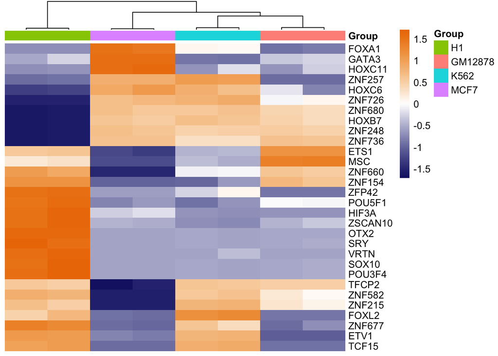

```r
top30 <- de_tfs %>% top_n(30, abs(log2FoldChange))

pheatmap(assay(rld)[rownames(top30),], color = colorRampPalette(c("#191d73", "white", "#ed7901"))(n = 100), cluster_rows=TRUE, show_rownames=TRUE, show_colnames = FALSE, cluster_cols=TRUE, annotation_col=as.data.frame(colData(deseq)["Group"]), scale = "row", treeheight_row = 0, treeheight_col = 25, border_color = NA)
```